# PSY T880: HW 1

Tinashe Michael Tapera

24 January 2017

> This exercise involves the Boston Dataset. To begin, load in the Boston data set. The Boston data set is part of the MASS library in R.

> The data set is contained in the object Boston.

|  | crim | zn | indus | chas | nox | rm | age | dis | rad | tax | ptratio | black | lstat | medv |
| --- | --- | --- | --- | --- | --- | --- | --- | --- | --- | --- | --- | --- | --- | --- |
| 1 | 0.00632 | 18.0 | 2.31 | 0 | 0.5380 | 6.575 | 65.2 | 4.0900 | 1 | 296 | 15.3 | 396.90 | 4.98 | 24.0 |
| 2 | 0.02731 | 0.0 | 7.07 | 0 | 0.4690 | 6.421 | 78.9 | 4.9671 | 2 | 242 | 17.8 | 396.90 | 9.14 | 21.6 |
| 3 | 0.02729 | 0.0 | 7.07 | 0 | 0.4690 | 7.185 | 61.1 | 4.9671 | 2 | 242 | 17.8 | 392.83 | 4.03 | 34.7 |
| 4 | 0.03237 | 0.0 | 2.18 | 0 | 0.4580 | 6.998 | 45.8 | 6.0622 | 3 | 222 | 18.7 | 394.63 | 2.94 | 33.4 |
| 5 | 0.06905 | 0.0 | 2.18 | 0 | 0.4580 | 7.147 | 54.2 | 6.0622 | 3 | 222 | 18.7 | 396.90 | 5.33 | 36.2 |
| 6 | 0.02985 | 0.0 | 2.18 | 0 | 0.4580 | 6.430 | 58.7 | 6.0622 | 3 | 222 | 18.7 | 394.12 | 5.21 | 28.7 |
| 7 | 0.08829 | 12.5 | 7.87 | 0 | 0.5240 | 6.012 | 66.6 | 5.5605 | 5 | 311 | 15.2 | 395.60 | 12.43 | 22.9 |
| 8 | 0.14455 | 12.5 | 7.87 | 0 | 0.5240 | 6.172 | 96.1 | 5.9505 | 5 | 311 | 15.2 | 396.90 | 19.15 | 27.1 |
| 9 | 0.21124 | 12.5 | 7.87 | 0 | 0.5240 | 5.631 | 100.0 | 6.0821 | 5 | 311 | 15.2 | 386.63 | 29.93 | 16.5 |
| 10 | 0.17004 | 12.5 | 7.87 | 0 | 0.5240 | 6.004 | 85.9 | 6.5921 | 5 | 311 | 15.2 | 386.71 | 17.10 | 18.9 |

[output cut: 496 more lines]

You can read about the data set using the call `?Boston`.

```r
?Boston
```

> How many rows are in this data set? How many columns? What do the rows and columns represent?

```r
dim(Boston)
```

```
[1] 506  14
```

The data set contains 506 rows and 14 columns, where rows represent observations and columns represent variables.

> Make some pairwise scatterplots of the predictors (columns) in this data set. Describe your findings.

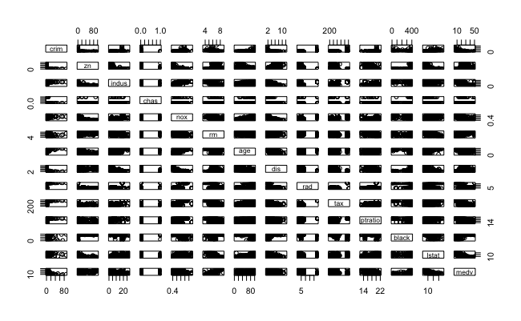

```r
pairs(Boston)
```

This scatter plot is too dense to be able to gain much from. However, we can see that “chas” is a dichotomous variable (Charles River) and that “rad” is probably not normally distributed (Radial highways). We can subset this plot to see more clearly.

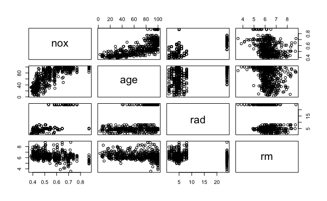

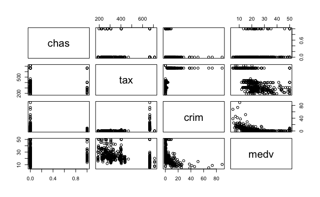

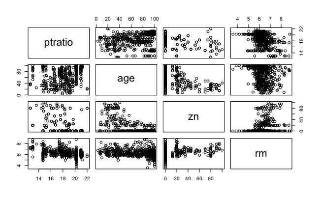

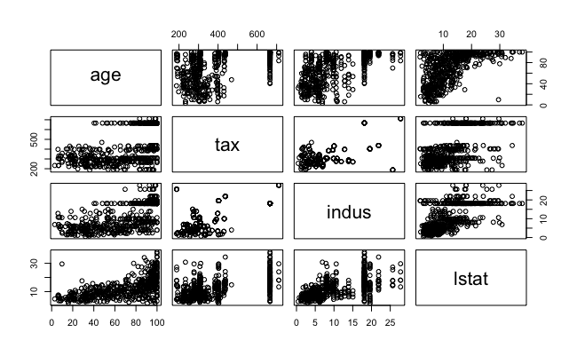

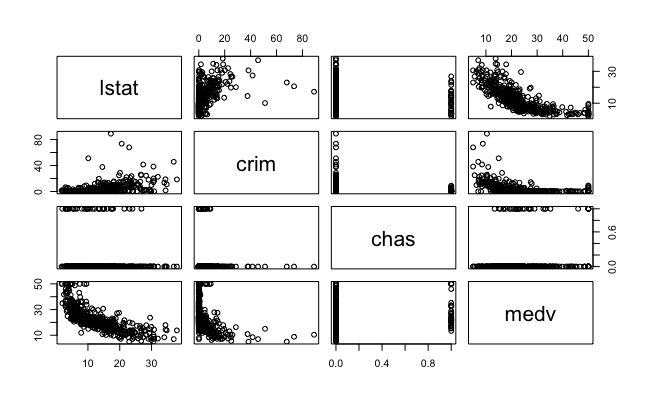

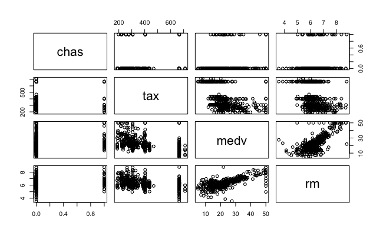

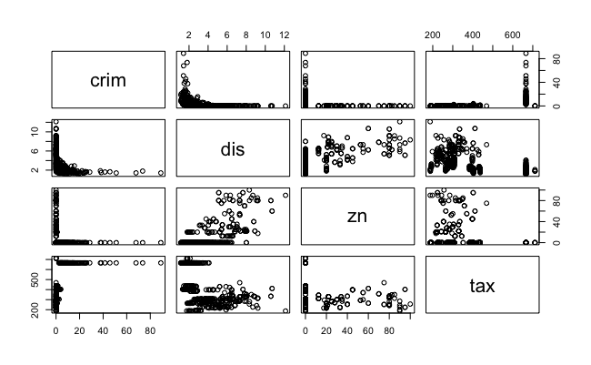

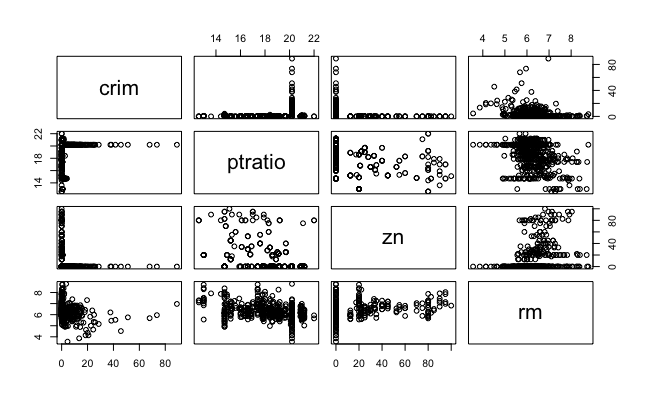

```r
# take a random sample of 4 columns each time and
# use this to fill in the plot with a few randomly
# selected variables
for(i in 1:8){pairs(Boston[,sample(1:14,4)])}
```

Some more observations:

- The variable Tax seems to have some inflated value around 680, as well as Rad around 24, and Indus at around 19. zn (Zone) is probably zero inflated.
- Age may be positively correlated with lstat.
- Age may be positively correlated with nox
- zn may be correlated with rm
- dis may be correlated with zn
- crim and dis may be non-linearly related. There is a very clear law, perhaps exponential decay law, between the two.
- medv and rm may be linearly related
- medv may be correlated with lstat, although it may be non-linear, perhaps logarithmic decay.

> What is the predictor in the data set most correlated with per capita crime rate? Explain the relationship.

We could visually inspect each scatter plot, but it would be more efficient to just run a loop of correlation tests, where we run a correlation between each variable and the target variable, and note down the coefficient and its p-value.

```r
correlations = data.frame(variable = NULL, coef = NULL, significant = NULL)
for(i in 2:dim(Boston)[2]){
  test = cor.test(Boston$crim,Boston[,i])
  variable = names(Boston)[i]
  coef = test$estimate
  significant = ifelse(test$p.value < 0.05, "YES", "NO")
  correlations = rbind(correlations,data.frame(variable,coef,significant, row.names = NULL))
}
kable(correlations)
```

| variable | coef | significant |
| --- | --- | --- |
| zn | -0.2004692 | YES |
| indus | 0.4065834 | YES |
| chas | -0.0558916 | NO |
| nox | 0.4209717 | YES |
| rm | -0.2192467 | YES |
| age | 0.3527343 | YES |
| dis | -0.3796701 | YES |
| rad | 0.6255051 | YES |
| tax | 0.5827643 | YES |
| ptratio | 0.2899456 | YES |
| black | -0.3850639 | YES |
| lstat | 0.4556215 | YES |
| medv | -0.3883046 | YES |

It looks like all of the variables except the chas variable are significantly correlated with crim. The chas variable is a categorical variable, so this makes sense. We can also order the observations to see which is most strongly correlated.

| variable | coef | significant |
| --- | --- | --- |
| rad | 0.6255051 | YES |
| tax | 0.5827643 | YES |
| lstat | 0.4556215 | YES |
| nox | 0.4209717 | YES |
| indus | 0.4065834 | YES |
| medv | -0.3883046 | YES |
| black | -0.3850639 | YES |
| dis | -0.3796701 | YES |
| age | 0.3527343 | YES |
| ptratio | 0.2899456 | YES |
| rm | -0.2192467 | YES |
| zn | -0.2004692 | YES |
| chas | -0.0558916 | NO |

From this table we can see that rad (accessibility to radial highways) is most strongly correlated with crim(per capita crime rate), followed by tax (full value property-tax rate per $10k) and lstat (% lower status of the population).

> How many of the suburbs in this data set bound the Charles River?

```r
table(Boston$chas)
```

```
  0   1
471  35
```

The table function counts how many of each observation there is in the variable. In this case, 0 represents Not bounding, and 1 represents Bounds. There are 35 suburbs that bound the river.

> What is the median pupil-teacher ratio among the towns of this data set?

```r
summary(Boston$ptratio)
```

```
   Min. 1st Qu.  Median    Mean 3rd Qu.    Max.
  12.60   17.40   19.05   18.46   20.20   22.00
```

The median pupil-teacher ratio is 19.05 (or just 19).

> Which suburb of Boston has lowest median value of owner-occupied homes? What are the values of the other predictors for that suburb, and how do those values compare to the overall ranges for those predictors? Comment on your findings.

```r
head(Boston[order(Boston$medv),])
```

|  | crim | zn | indus | chas | nox | rm | age | dis | rad | tax | ptratio | black | lstat | medv |
| --- | --- | --- | --- | --- | --- | --- | --- | --- | --- | --- | --- | --- | --- | --- |
| 399 | 38.35180 | 0 | 18.10 | 0 | 0.693 | 5.453 | 100.0 | 1.4896 | 24 | 666 | 20.2 | 396.90 | 30.59 | 5.0 |
| 406 | 67.92080 | 0 | 18.10 | 0 | 0.693 | 5.683 | 100.0 | 1.4254 | 24 | 666 | 20.2 | 384.97 | 22.98 | 5.0 |
| 401 | 25.04610 | 0 | 18.10 | 0 | 0.693 | 5.987 | 100.0 | 1.5888 | 24 | 666 | 20.2 | 396.90 | 26.77 | 5.6 |
| 400 | 9.91655 | 0 | 18.10 | 0 | 0.693 | 5.852 | 77.8 | 1.5004 | 24 | 666 | 20.2 | 338.16 | 29.97 | 6.3 |
| 415 | 45.74610 | 0 | 18.10 | 0 | 0.693 | 4.519 | 100.0 | 1.6582 | 24 | 666 | 20.2 | 88.27 | 36.98 | 7.0 |
| 490 | 0.18337 | 0 | 27.74 | 0 | 0.609 | 5.414 | 98.3 | 1.7554 | 4 | 711 | 20.1 | 344.05 | 23.97 | 7.0 |

```r
apply(Boston, 2, summary)
```

```
            crim     zn indus    chas    nox    rm    age    dis
Min.     0.00632   0.00  0.46 0.00000 0.3850 3.561   2.90  1.130
1st Qu.  0.08204   0.00  5.19 0.00000 0.4490 5.886  45.02  2.100
Median   0.25650   0.00  9.69 0.00000 0.5380 6.208  77.50  3.207
Mean     3.61400  11.36 11.14 0.06917 0.5547 6.285  68.57  3.795
3rd Qu.  3.67700  12.50 18.10 0.00000 0.6240 6.624  94.07  5.188
Max.    88.98000 100.00 27.74 1.00000 0.8710 8.780 100.00 12.130
           rad   tax ptratio  black lstat  medv
Min.     1.000 187.0   12.60   0.32  1.73  5.00
1st Qu.  4.000 279.0   17.40 375.40  6.95 17.02
Median   5.000 330.0   19.05 391.40 11.36 21.20
Mean     9.549 408.2   18.46 356.70 12.65 22.53
3rd Qu. 24.000 666.0   20.20 396.20 16.96 25.00
Max.    24.000 711.0   22.00 396.90 37.97 50.00
```

The suburbs 399 and 406 both have the minimum median value at 5.0; We’ll focus on suburb 399.

Overall, these statistics suggest that suburb 399 is a poorer suburb, with a very dense population, high pollution, and substantially antiquated infrastructure.